# Tarea 7

Silvia García Lara

2024-11-06

## Mortalidad observada en 6 experimentos con 50 células dosificando 6 sustancias

Para ello cargamos el conjunto de datos y lo almacenamos en un data frame, para poder ajustar los 3 modelos pedidos (Nulo, Saturado y Lineal) para cada conjunto de datos, con ayuda de un bucle.

Tras obtener los AIC de cada modelo y conjunto, los almacenamos en otro data.frame para poder compararlos.

```
##    Variable   Modelo        AIC
## 1        y1     Nulo 1344.24523
## 2        y1 Saturado  128.90911
## 3        y1   Lineal   90.04621
## 4        y2     Nulo  156.07781
## 5        y2 Saturado  182.61005
## 6        y2   Lineal  158.00601
## 7        y3     Nulo  565.51637
## 8        y3 Saturado  159.12237
## 9        y3   Lineal  146.00962
## 10       y4     Nulo 1320.65583
## 11       y4 Saturado  131.69952
## 12       y4   Lineal  100.38414
## 13       y5     Nulo 1247.99580
## 14       y5 Saturado  120.15091
## 15       y5   Lineal   80.72711
## 16       y6     Nulo 1009.63766
## 17       y6 Saturado  162.45291
## 18       y6   Lineal  141.46080
```

Realizamos las predicciones de cada modelo en cada conjunto de datos y para la representación calculamos la proporción de Mortalidad y vemos como cada uno de los modelos se ajusta a los datos.

En azul vemos dibjuado el modelo Nulo, en verde el saturado y en rojo el lineal.

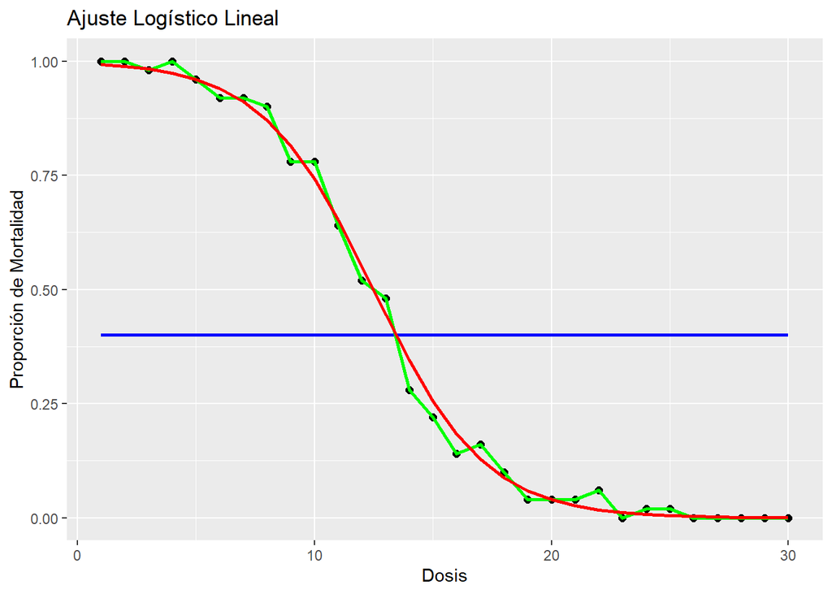

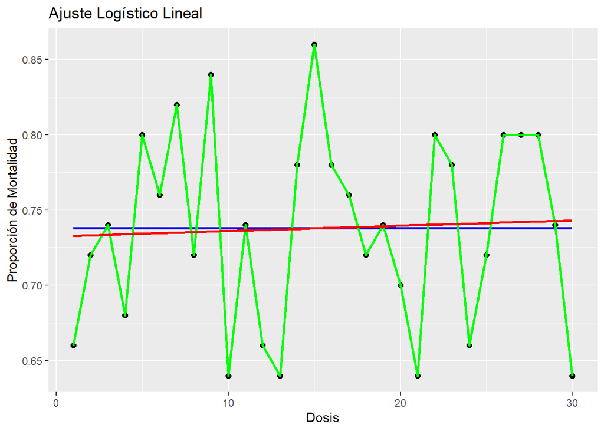

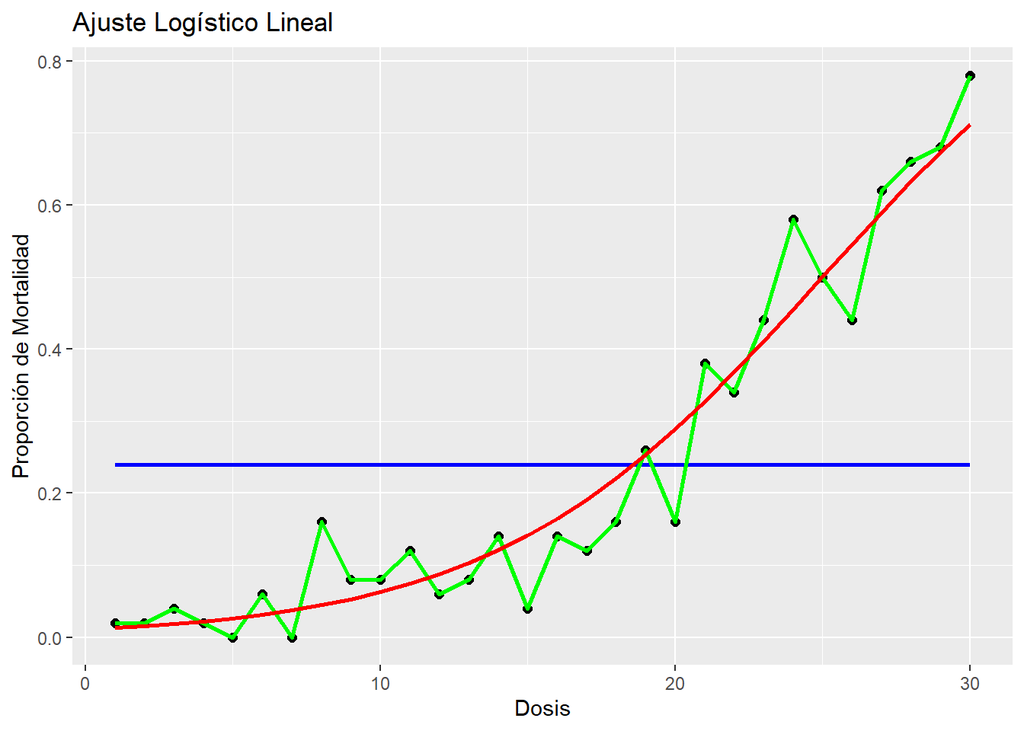

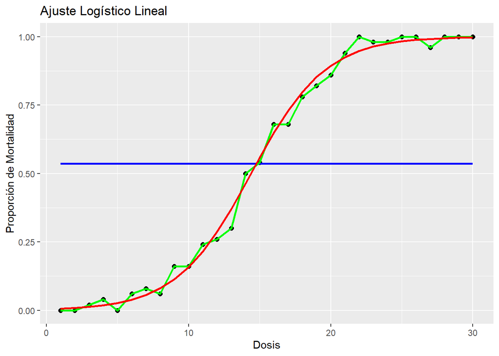

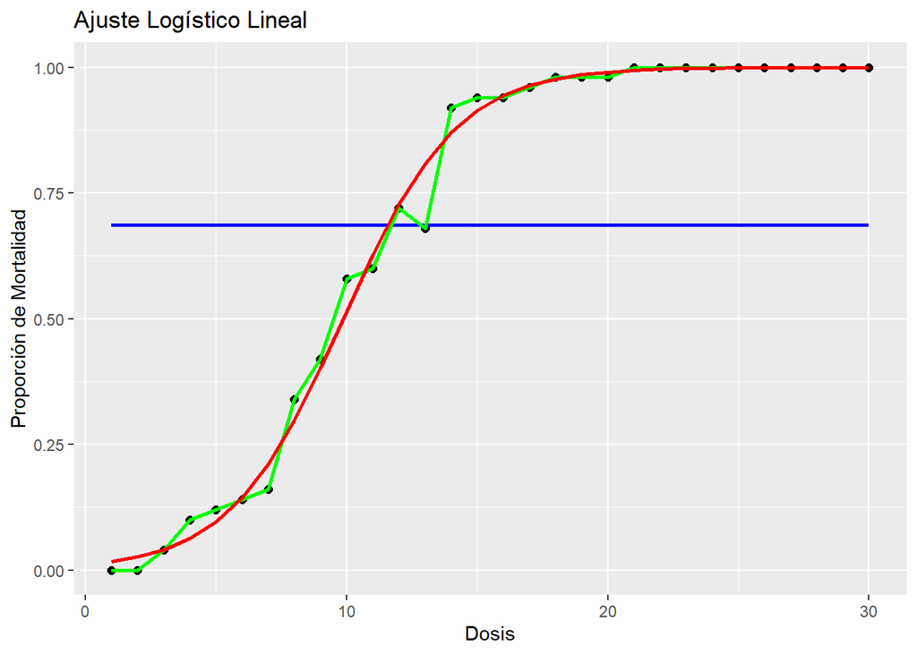

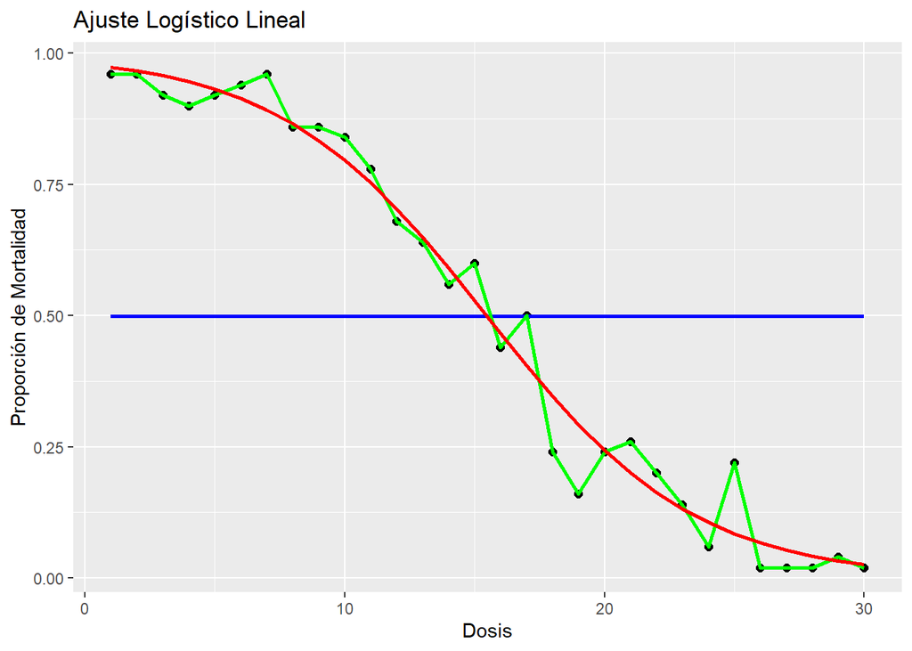

Para el ajuste lineal a los datos en la columna y1

- Trabajando Numéricamente

Representa la logverosimilitud y estima el máximo verosímil.

```
## Estimación del máximo verosímil:
```

```
## Beta0: 5.307694
```

```
## Beta1: -0.4250344
```

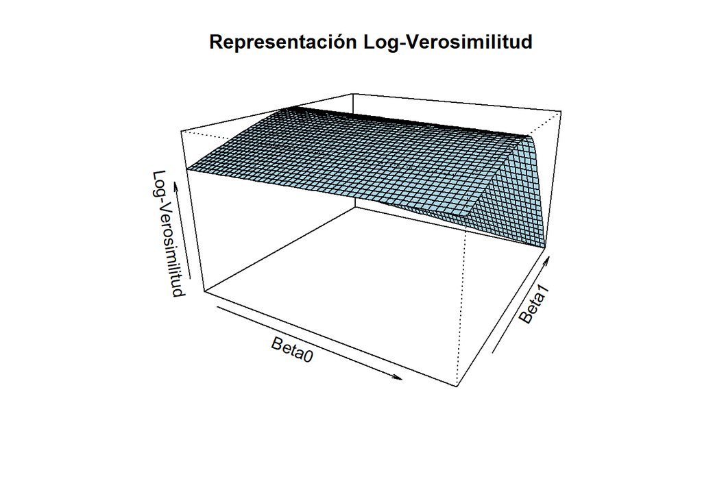

Los intervalos de confianza al 95% tipo Wald para los parámetros beta[1] y beta[2] son:

[output not shown]

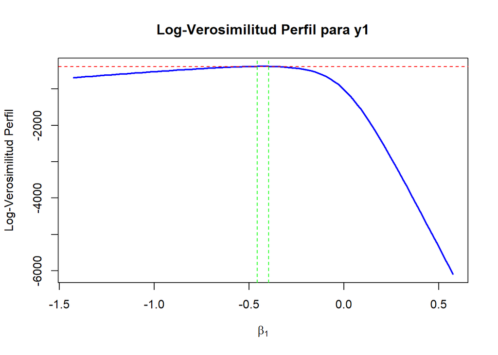

```
## Intervalo de confianza al 95% para beta1 basado en la verosimilitud perfil: -0.4553374 -0.3947314
```

- Trabajando con el ajuste dado por la función glm

```
## [1] "Intervalos de confianza tipo Wald:"
```

```
##                  2.5 %     97.5 %
## (Intercept)  4.7230747  5.8911642
## x           -0.4692039 -0.3808306
```

```
## [1] "Intervalos de confianza por verosimilitud perfil:"
```

```
##                  2.5 %     97.5 %
## (Intercept)  4.7474308  5.9171559
## x           -0.4713023 -0.3828069
```

Podemos comprobar que los intervalos obtenidos se parecen al obtenido numéricamente.

```r
#Calcular los valores de x para LD30, LD50 y LD80
LD50 <- (log(0.50 / (1 - 0.50)) - beta0) / beta1
LD30 <- (log(0.30 / (1 - 0.30)) - beta0) / beta1
LD80 <- (log(0.80 / (1 - 0.80)) - beta0) / beta1
```

```
##
## Valores de LD:
```

```
## LD50: 12.48683
```

```
## LD30: 14.48039
```

```
## LD80: 9.225097
```

```r
# Calcular los intervalos de confianza para LD30, LD50 y LD80 usando los intervalos de los coeficientes
LD50_lower <- (log(0.50 / (1 - 0.50)) - ic_verosimilitud[1, 2]) / ic_verosimilitud[2, 1]
LD50_upper <- (log(0.50 / (1 - 0.50)) - ic_verosimilitud[1, 1]) / ic_verosimilitud[2, 2]

LD30_lower <- (log(0.30 / (1 - 0.30)) - ic_verosimilitud[1, 2]) / ic_verosimilitud[2, 1]
LD30_upper <- (log(0.30 / (1 - 0.30)) - ic_verosimilitud[1, 1]) / ic_verosimilitud[2, 2]

LD80_lower <- (log(0.80 / (1 - 0.80)) - ic_verosimilitud[1, 2]) / ic_verosimilitud[2, 1]
LD80_upper <- (log(0.80 / (1 - 0.80)) - ic_verosimilitud[1, 1]) / ic_verosimilitud[2, 2]
```

```
##
## Intervalos de confianza para los valores de LD:
```

```
## LD50 Intervalo de confianza: 12.55491 a 12.40163
```

```
## LD30 Intervalo de confianza: 14.35269 a 14.61501
```

```
## LD80 Intervalo de confianza: 9.613493 a 8.78024
```

```r
# Calcular la probabilidad para x = 8 y x = 14
probabilidad_x8 <- 1 / (1 + exp(-(beta0 + beta1 * 8)))
probabilidad_x14 <- 1 / (1 + exp(-(beta0 + beta1 * 14)))
```

```
##
## Probabilidad para x=8: 0.8706797
```

```
## Probabilidad para x=14: 0.3445412
```

```r
# Calcular IC para x = 8
probabilidad_x8_ic <- probabilidad_ic(8, ic_verosimilitud[1, 1], ic_verosimilitud[1, 2], ic_verosimilitud[2, 1], ic_verosimilitud[2, 2])

# Calcular IC para x = 14
probabilidad_x14_ic <- probabilidad_ic(14, ic_verosimilitud[1, 1], ic_verosimilitud[1, 2], ic_verosimilitud[2, 1], ic_verosimilitud[2, 2])
```

```
##
## Intervalo de confianza para la probabilidad en x=8: 0.726515 0.9455612
```

```
## Intervalo de confianza para la probabilidad en x=14: 0.1357788 0.6359571
```

## Mortalidad observada en 5 experimentos con 100 células de 2 tipos dosificando 5 sustancias

```
## Mejor modelo para y1 :  modelo_dosis_lineal
## AIC del mejor modelo: 100.3425
```

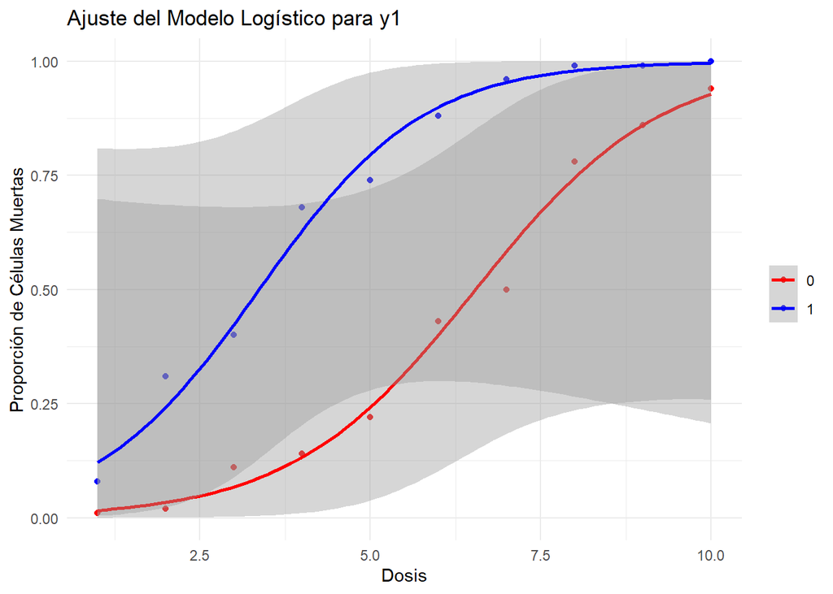

```
## Mejor modelo para y2 :  modelo_dosis_lineal
## AIC del mejor modelo: 78.51838
```

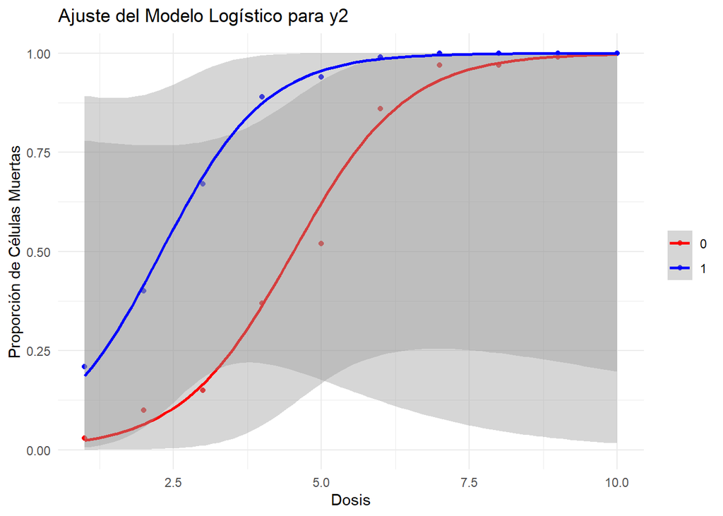

```
## Mejor modelo para y3 :  modelo_dosis_lineal
## AIC del mejor modelo: 58.72028
```

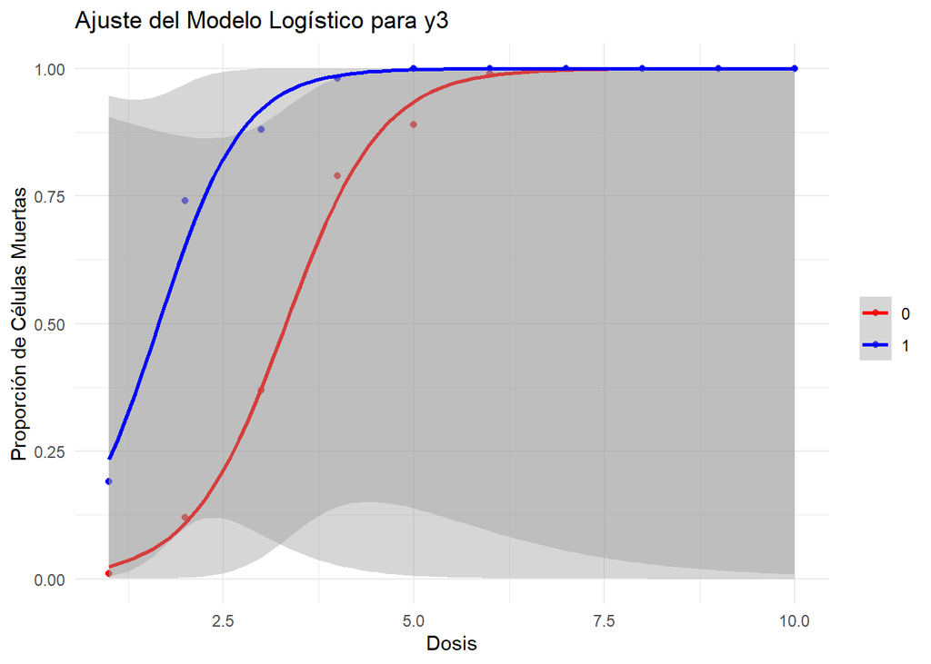

```
## Mejor modelo para y4 :  modelo_dosis_lineal
## AIC del mejor modelo: 121.3311
```

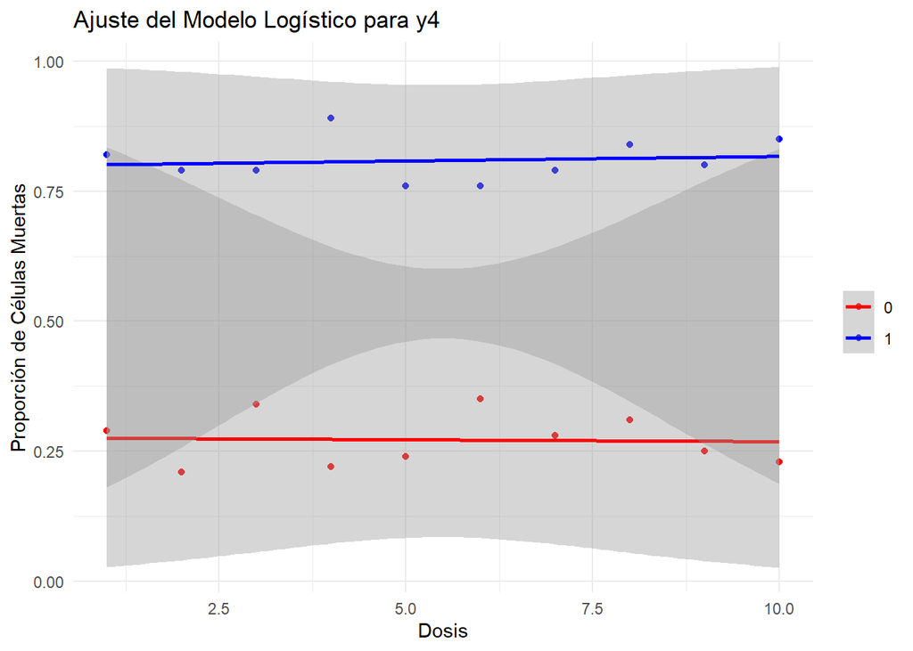

```
## Mejor modelo para y5 :  modelo_saturado
## AIC del mejor modelo: 77.51739
```

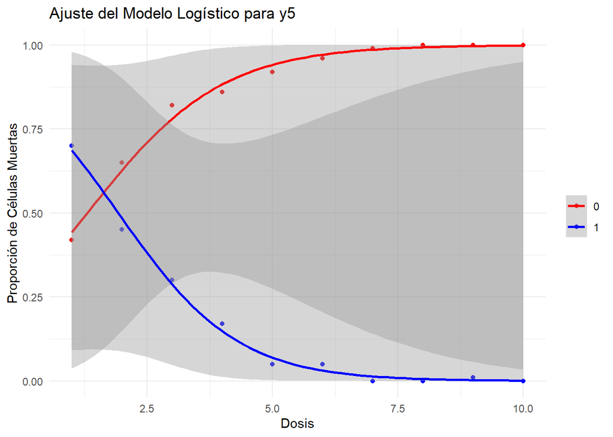